# Portfolio in R

Author: Leonardo Tozo Bisinoto

2/28/2020

## Let’s programming in R?

Hello,  
This is part of my personal portfolio, my intention with this series of notebooks is to keep practicing and improving my A.I & Machine Learning skills.

Leonardo Tozo Bisinoto  
MBA in Artificial Intelligence & Machine Learning  
LinkedIn: https://www.linkedin.com/in/leotozo/  
Github: https://github.com/leotozo

To help to understand any command or function, we can refer to the R documentation in anytime using the `?` and `help()` commands.

```
 ?mean
 help(mean)
```

mean is the function name, replace it for the function or the command that you wish to refer.

## VARIABLES ATTRIBUTION

In R we make variables attribution using `<-` or as in other languages using `=`

```r
a <- 1
a     # prints the a variable
```

```
[1] 1
```

```r
b = 2
b     # prints the b variable
```

```
[1] 2
```

## DATA TYPES

### character

```r
"a"
```

```
[1] "a"
```

```r
"1"
```

```
[1] "1"
```

```r
"positivo"
```

```
[1] "positivo"
```

### numeric

```r
1
```

```
[1] 1
```

```r
0.10
```

```
[1] 0.1
```

```r
0.95
```

```
[1] 0.95
```

```r
pi
```

```
[1] 3.141593
```

### integer

```r
1L
```

```
[1] 1
```

```r
5L
```

```
[1] 5
```

```r
10L
```

```
[1] 10
```

### complex

```r
2 + 5i
```

```
[1] 2+5i
```

### logical

```r
TRUE
```

```
[1] TRUE
```

```r
FALSE
```

```
[1] FALSE
```

To know the class of an object we use the function `class()`

```r
x <- 1
class(x)
```

```
[1] "numeric"
```

```r
y <- "a"
class(y)
```

```
[1] "character"
```

```r
z <- TRUE
class(z)
```

```
[1] "logical"
```

We can also use the function `is.()`

```r
is.integer(x)
```

```
[1] FALSE
```

```r
is.numeric(x)
```

```
[1] TRUE
```

```r
is.character(x)
```

```
[1] FALSE
```

```r
is.array(x)
```

```
[1] FALSE
```

```r
is.data.frame(x)
```

```
[1] FALSE
```

## BASIC ARITHMETIC OPERATIONS

Following are some basic arithmetic operations.

### addition

```r
1 + 1
```

```
[1] 2
```

### subtraction

```r
4 - 2
```

```
[1] 2
```

### multiplication

```r
2 * 3
```

```
[1] 6
```

### division

```r
5 / 3
```

```
[1] 1.666667
```

### exponentiation

```r
4 ^ 2
```

```
[1] 16
```

### division remainder of 5 / 3

```r
5 %% 3
```

```
[1] 2
```

### entire part of the 5 by 3 division

```r
5 %/% 3
```

```
[1] 1
```

## ARRAY

To create a vector we use the `c` function, it means “combine”.

```r
vet1 <- c(1, 2, 3, 4)
vet2 <- c("a", "b", "c")

vet1
```

```
[1] 1 2 3 4
```

```r
vet2
```

```
[1] "a" "b" "c"
```

A vector always has the same class as the objects it holds.

```r
class(vet1)
```

```
[1] "numeric"
```

```r
class(vet2)
```

```
[1] "character"
```

We can do vector operations in a very intuitive way.

```r
vet1
```

```
[1] 1 2 3 4
```

```r
vet1 - 1
```

```
[1] 0 1 2 3
```

When we do `vet1 - 1`, R subtracts 1 from each of the elements of the vector. The same happens when we do any arithmetic operation with vectors in R.

```r
vet1 / 2
```

```
[1] 0.5 1.0 1.5 2.0
```

```r
vet1 * 10
```

```
[1] 10 20 30 40
```

We can also do operations that involve more than one vector:

```r
vet1 * vet1
```

```
[1]  1  4  9 16
```

In this case, R will align the two vectors and multiply element by element. This can get a little confusing when the two vectors are not the same size:

```r
vet2 <- 1:3
vet1 * vet2
```

```
[1] 1 4 9 4
```

The R aligned the two vectors and, as they did not have the same size, it was repeating the smaller vector until completing the larger vector. This behavior is called recycling and is useful for doing element-by-element operations (vectorized), but can sometimes be confusing.

## MATRICES

To create a matrix, we use the `matrix` function. The function `dim ()` returns the dimension of the object.

```r
m <- matrix(1:6, nrow = 2, ncol = 3)
m
```

```
     [,1] [,2] [,3]
[1,]    1    3    5
[2,]    2    4    6
```

```r
dim(m)
```

```
[1] 2 3
```

Some useful operations:

### selects the second row of the matrix

```r
m[2, ]
```

```
[1] 2 4 6
```

### select the second column

```r
m[ , 2]
```

```
[1] 3 4
```

### selects the first element of the second column

```r
m[1, 2]
```

```
[1] 3
```

### matrix transpose

```r
t(m)
```

```
     [,1] [,2]
[1,]    1    2
[2,]    3    4
[3,]    5    6
```

## FACTORS

Factors are vectors of integers that have labels (levels). They are useful for representing a categorical variable (nominal and ordinal). In modeling, they are treated in a special way in functions like `lm ()` and `glm ()`

```r
sexo <- c("M", "H", "H", "H", "M", "M", "H")
fator <- as.factor(sexo)
fator
```

```
[1] M H H H M M H
Levels: H M
```

```r
as.numeric(fator)
```

```
[1] 2 1 1 1 2 2 1
```

The `levels ()` function returns the factor labels:

```r
levels(fator)
```

```
[1] "H" "M"
```

## SPECIAL VALUES

There are values reserved to represent missing, infinite data, and mathematical indefinitions. `NaN` (Not a Number) is the result of an invalid mathematical operation.

```r
0/0
```

```
[1] NaN
```

`NULL` is the emptiness of R. It is as if the object did not exist.

```r
NULL
```

```r
a = NULL

a
```

Note that a vector even without elements is not `NULL`.

```r
is.null(integer(length = 0))
```

```
[1] FALSE
```

`NA` (Not Available) is a logical constant for R. NA can be converted to almost all types of R. vectors. It is mainly used to indicate missing values.

```r
NA
```

```
[1] NA
```

```r
as.numeric(c("1", "2", "a"))
```

```
[1]  1  2 NA
```

`Inf` (Infinite) is the result of mathematical operations whose limit is infinite.

```r
1/0
```

```
[1] Inf
```

```r
1/Inf
```

```
[1] 0
```

```r
x <- c(NaN, Inf, 1, 2, 3, NA)
is.na(x)
```

```
[1]  TRUE FALSE FALSE FALSE FALSE  TRUE
```

```r
is.nan(x)
```

```
[1]  TRUE FALSE FALSE FALSE FALSE FALSE
```

We can replace the missing values by the average.

```r
x = c(10, 5, 5, 10, NA, NA)
x
```

```
[1] 10  5  5 10 NA NA
```

```r
x[is.na(x)] = mean(x,na.rm=TRUE)
x
```

```
[1] 10.0  5.0  5.0 10.0  7.5  7.5
```

## FILTERING DATA FROM STRUCTURE

The data is filtered into different types of structures using square brackets.

Filtering data from the `mtcars` dataset

```r
mtcars
```

```
                     mpg cyl  disp  hp drat    wt  qsec vs am gear carb
Mazda RX4           21.0   6 160.0 110 3.90 2.620 16.46  0  1    4    4
Mazda RX4 Wag       21.0   6 160.0 110 3.90 2.875 17.02  0  1    4    4
Datsun 710          22.8   4 108.0  93 3.85 2.320 18.61  1  1    4    1
Hornet 4 Drive      21.4   6 258.0 110 3.08 3.215 19.44  1  0    3    1
Hornet Sportabout   18.7   8 360.0 175 3.15 3.440 17.02  0  0    3    2
Valiant             18.1   6 225.0 105 2.76 3.460 20.22  1  0    3    1
Duster 360          14.3   8 360.0 245 3.21 3.570 15.84  0  0    3    4
Merc 240D           24.4   4 146.7  62 3.69 3.190 20.00  1  0    4    2
Merc 230            22.8   4 140.8  95 3.92 3.150 22.90  1  0    4    2
Merc 280            19.2   6 167.6 123 3.92 3.440 18.30  1  0    4    4
Merc 280C           17.8   6 167.6 123 3.92 3.440 18.90  1  0    4    4
Merc 450SE          16.4   8 275.8 180 3.07 4.070 17.40  0  0    3    3
Merc 450SL          17.3   8 275.8 180 3.07 3.730 17.60  0  0    3    3
Merc 450SLC         15.2   8 275.8 180 3.07 3.780 18.00  0  0    3    3
Cadillac Fleetwood  10.4   8 472.0 205 2.93 5.250 17.98  0  0    3    4
Lincoln Continental 10.4   8 460.0 215 3.00 5.424 17.82  0  0    3    4
Chrysler Imperial   14.7   8 440.0 230 3.23 5.345 17.42  0  0    3    4
Fiat 128            32.4   4  78.7  66 4.08 2.200 19.47  1  1    4    1
Honda Civic         30.4   4  75.7  52 4.93 1.615 18.52  1  1    4    2
Toyota Corolla      33.9   4  71.1  65 4.22 1.835 19.90  1  1    4    1
Toyota Corona       21.5   4 120.1  97 3.70 2.465 20.01  1  0    3    1
Dodge Challenger    15.5   8 318.0 150 2.76 3.520 16.87  0  0    3    2
AMC Javelin         15.2   8 304.0 150 3.15 3.435 17.30  0  0    3    2
Camaro Z28          13.3   8 350.0 245 3.73 3.840 15.41  0  0    3    4
Pontiac Firebird    19.2   8 400.0 175 3.08 3.845 17.05  0  0    3    2
Fiat X1-9           27.3   4  79.0  66 4.08 1.935 18.90  1  1    4    1
Porsche 914-2       26.0   4 120.3  91 4.43 2.140 16.70  0  1    5    2
Lotus Europa        30.4   4  95.1 113 3.77 1.513 16.90  1  1    5    2
Ford Pantera L      15.8   8 351.0 264 4.22 3.170 14.50  0  1    5    4
Ferrari Dino        19.7   6 145.0 175 3.62 2.770 15.50  0  1    5    6
Maserati Bora       15.0   8 301.0 335 3.54 3.570 14.60  0  1    5    8
Volvo 142E          21.4   4 121.0 109 4.11 2.780 18.60  1  1    4    2
```

```r
mtcars[2,5]
```

```
[1] 3.9
```

```r
mtcars[2:4,5]
```

```
[1] 3.90 3.85 3.08
```

```r
mtcars[2:4,5:7]
```

```
               drat    wt  qsec
Mazda RX4 Wag  3.90 2.875 17.02
Datsun 710     3.85 2.320 18.61
Hornet 4 Drive 3.08 3.215 19.44
```

```r
mtcars[8:9, c(1,2,4)]
```

```
           mpg cyl hp
Merc 240D 24.4   4 62
Merc 230  22.8   4 95
```

```r
mtcars[2:4, c("mpg", "wt")]
```

```
                mpg    wt
Mazda RX4 Wag  21.0 2.875
Datsun 710     22.8 2.320
Hornet 4 Drive 21.4 3.215
```

## LISTS

Creating a list passing the following parameters: sequence from 1 to 5, the string “z”, the Boolean value TRUE and a vector containing a and b.

```r
x <- list(1:5, "Z", TRUE, c("a", "b"))
x
```

```
[[1]]
[1] 1 2 3 4 5

[[2]]
[1] "Z"

[[3]]
[1] TRUE

[[4]]
[1] "a" "b"
```

## SEQUENCES

Creating a sequence of numbers from 1 to 20:

```r
1:20
```

```
 [1]  1  2  3  4  5  6  7  8  9 10 11 12 13 14 15 16 17 18 19 20
```

Now we are going to create a sequence of real numbers. The result is a vector of real numbers starting with pi (3.142 …) and increasing in increments of 1. The limit of 10 is never reached, since the next number in our sequence would be greater than 10.

```r
pi:10
```

```
[1] 3.141593 4.141593 5.141593 6.141593 7.141593 8.141593 9.141593
```

We can also create a sequence using the `seq ()` function.

```r
seq(1, 20)
```

```
 [1]  1  2  3  4  5  6  7  8  9 10 11 12 13 14 15 16 17 18 19 20
```

Creating sequence vector:

```r
seq(0, 10, by=0.5)
```

```
 [1]  0.0  0.5  1.0  1.5  2.0  2.5  3.0  3.5  4.0  4.5  5.0  5.5  6.0  6.5
[15]  7.0  7.5  8.0  8.5  9.0  9.5 10.0
```

```r
seq(5, 10, length=30)
```

```
 [1]  5.000000  5.172414  5.344828  5.517241  5.689655  5.862069  6.034483
 [8]  6.206897  6.379310  6.551724  6.724138  6.896552  7.068966  7.241379
[15]  7.413793  7.586207  7.758621  7.931034  8.103448  8.275862  8.448276
[22]  8.620690  8.793103  8.965517  9.137931  9.310345  9.482759  9.655172
[29]  9.827586 10.000000
```

Creating sequence using the `rep ()` function. Creates a sequence repeating 40 times the value passed 0.

```r
rep(0, times = 40)
```

```
 [1] 0 0 0 0 0 0 0 0 0 0 0 0 0 0 0 0 0 0 0 0 0 0 0 0 0 0 0 0 0 0 0 0 0 0 0
[36] 0 0 0 0 0
```

Repeating the vector c (0, 1, 2) 10 times.

```r
rep(c(0, 1, 2), times = 10)
```

```
 [1] 0 1 2 0 1 2 0 1 2 0 1 2 0 1 2 0 1 2 0 1 2 0 1 2 0 1 2 0 1 2
```

Repeating each element of the vector c (0, 1, 2) 10 times.

```r
rep(c(0, 1, 2), each = 10)
```

```
 [1] 0 0 0 0 0 0 0 0 0 0 1 1 1 1 1 1 1 1 1 1 2 2 2 2 2 2 2 2 2 2
```

## CONTROL FLOW

The R has flow controls that are very important when programming, they are: if’s, else’s, for’s, while’s etc.

### IF e ELSE

R will only execute what is in the expression inside the braces `{}` if what is inside the brackets `()` returns `TRUE`, then only if the object `x` is equal to 1.

```r
x <- 1

if(x == 1) {
  Sys.time()
}
```

```
[1] "2020-02-28 15:59:49 -03"
```

```r
if(x < 0) {

  sinal <- "negativo"

} else if(x == 0) {

  sinal <- "neutro"

} else if(x > 0) {

  sinal <- "positivo"
}

sinal
```

```
[1] "positivo"
```

### FOR

Using the `for` to add all the elements of a vector.

```r
x <- 1:10   # Cria um vetor com a sequência 1, 2, ..., 10.
soma <- 0

for(i in 1:10) {
  soma <- soma + x[i]
}

soma
```

```
[1] 55
```

We can also directly use the `sum ()` function.

```r
sum(x)
```

```
[1] 55
```

Using the `print ()` function to print the result of dividing each element of a vector by two on the screen.

```r
vetor <- 30:35
indices <- seq_along(vetor) # creates the index vector according to the size of
                            # the vector object.
for(i in indices) {
  print(vetor[1:i] / 2)
}
```

```
[1] 15
[1] 15.0 15.5
[1] 15.0 15.5 16.0
[1] 15.0 15.5 16.0 16.5
[1] 15.0 15.5 16.0 16.5 17.0
[1] 15.0 15.5 16.0 16.5 17.0 17.5
```

## DATE AND TIME

There are some functions for obtaining the current time and date.

```
Sys.time() - returns the absolute date / time that can be converted to multiple time zones and can return different days.
Sys.Date() - returns the current date in the current time zone.
Sys.timezone() - returns the time zone.
```

```r
Sys.time()
```

```
[1] "2020-02-28 15:59:49 -03"
```

```r
Sys.Date()
```

```
[1] "2020-02-28"
```

```r
Sys.timezone()
```

```
[1] "America/Sao_Paulo"
```

Dates are represented by the `Date` class and the hours are represented by the `POSIXct` and `POSIXlt` classes.

Internally, dates are stored as the number of days since 1970-Jan-01 and times are stored as the number of seconds since 1970-Jan-01 (for “POSIXct”) or a list of seconds, minutes, hours, etc. (for “POSIXlt”).

Using the `as.Date ()` function to convert strings to dates.

```r
mydates <- as.Date(c("2007-06-22", "2004-02-13"))
mydates
```

```
[1] "2007-06-22" "2004-02-13"
```

```r
class(mydates)
```

```
[1] "Date"
```

Performing operations between dates. Number of days between two dates.

```r
days <- mydates[1] - mydates[2]
days
```

```
Time difference of 1225 days
```

The symbols below can be used with the `format()` function to return dates.

- `%d` returns the day in number, example: 01-31 (month/day)
- `%a` returns the abbreviated day of the week, example: Mon
- `%A` returns the day of the week without abbreviation, example: Monday
- `%m` returns the month, example: 00-12
- `%b` returns the abbreviated month, example: Jan
- `%B` returns the month without abbreviation, example: January
- `%y` returns the year in 2-digits, example: 07
- `%Y` returns the year in 4-digits, example: 2007

Printing today’s date and using the `format()` function

```r
today <- Sys.Date()

today
```

```
[1] "2020-02-28"
```

```r
format(today, format="%B %d %Y")
```

```
[1] "February 28 2020"
```

## CONVERTING DATES

### Character to Date

As previously done, we can use the `as.Date()` function to convert strings to dates. The format is `as.Date(x," format ")`, where `x` is the character/string and `format` is the appropriate format.

The default format is `yyyy-mm-dd`. We can convert the date using other formats, for example: `'mm/dd/yyyy'`.

```r
strDates <- c("01/05/1965", "08/16/1975")
class(strDates)
```

```
[1] "character"
```

```r
dates <- as.Date(strDates, "%m/%d/%Y")
class(dates)
```

```
[1] "Date"
```

```r
mydates <- as.Date(c("2007-06-22", "2004-02-13"))

mydates
```

```
[1] "2007-06-22" "2004-02-13"
```

```r
class(mydates)
```

```
[1] "Date"
```

### Date to Character

We can convert dates to characters using the `as.Character()` function

```r
class(dates)
```

```
[1] "Date"
```

```r
strDates <- as.character(dates)

class(strDates)
```

```
[1] "character"
```

## USING THE LUBRIDATE

There is a package that helps us to manipulate time.

Lubricate brings several functions to extract the components of an object of the class `date`

```
second() - extracts the seconds.
minute() - extracts the minutes.
hour() - extracts the hour.
wday() - extracts the day of the week.
mday() - extracts the day of the month.
month() - extracts the month.
year() - extracts the year.
```

```r
data <- dmy(01041991)
data
```

```
[1] "1991-04-01"
```

```r
hour(data) <- 20
data
```

```
[1] "1991-04-01 20:00:00 UTC"
```

There are also functions to extract the date at the time of execution.

```r
today()
```

```
[1] "2020-02-28"
```

```r
now()
```

```
[1] "2020-02-28 15:59:50 -03"
```

```r
bday <- ymd_hms(19890729030142)
bday
```

```
[1] "1989-07-29 03:01:42 UTC"
```

```r
second(bday)
```

```
[1] 42
```

```r
day(bday)
```

```
[1] 29
```

```r
month(bday)
```

```
[1] 7
```

```r
year(bday)
```

```
[1] 1989
```

```r
wday(bday)
```

```
[1] 7
```

```r
wday(bday, label = TRUE)
```

```
[1] Sat
Levels: Sun < Mon < Tue < Wed < Thu < Fri < Sat
```

## Time Zones

An inherent feature of dates is the time zone. If we are working with event dates in Brazil and Scotland, for example, it is necessary to verify that the values follow the same time zone. In addition, when the exact date of an event is relevant, we may need to convert times to other time zones to communicate results in other countries.

To do these things, `lubidate` provides the `with_tz()` and `force_tz()` functions.

```r
italian_GP <- ymd_hms("2019-09-08 15:10:00", tz = "Europe/Rome")
italian_GP
```

```
[1] "2019-09-08 15:10:00 CEST"
```

```r
# Devolve qual seria a data em outro fuso

with_tz(italian_GP, tzone = "GMT")
```

```
[1] "2019-09-08 13:10:00 GMT"
```

```r
with_tz(italian_GP, tzone = "America/Sao_Paulo")
```

```
[1] "2019-09-08 10:10:00 -03"
```

```r
# Altera o fuso sem mudar a hora

force_tz(italian_GP, tzone = "GMT")
```

```
[1] "2019-09-08 15:10:00 GMT"
```

## Date operations

The ‘lubidate’ package also has functions to calculate intervals and perform arithmetic operations with dates.

### Intervals

Intervals can be saved on objects with class `interval`.

```r
inicio <- dmy("01-04-1991")
evento <- dmy("31-10-1993")

sobrev <- interval(inicio, evento)
sobrev
```

```
[1] 1991-04-01 UTC--1993-10-31 UTC
```

```r
class(sobrev)
```

```
[1] "Interval"
attr(,"package")
[1] "lubridate"
```

We can check if two intervals intersect with the function `int_overlaps()`

```r
# Outra forma de definir um intervalo: o operador %--%
intervalo_1 <- dmy("01-02-2003") %--% dmy("02-03-2005")

intervalo_2 <- dmy("04-05-2004") %--% dmy("12-03-2012")

int_overlaps(intervalo_1, intervalo_2)
```

```
[1] TRUE
```

### Arithmetic with dates

Here are some examples of arithmetic operations that you can do using `lubidate` functions.

```r
# Somando datas

data <- dmy(31012000)

data + ddays(1)
```

```
[1] "2000-02-01"
```

```r
data + dyears(1)
```

```
[1] "2001-01-30"
```

```r
data + months(1)  # Operações que resultam em datas inválidas geram NAs.
```

```
[1] NA
```

```r
# Criando datas recorrentes

reuniao <- dmy("18-03-2017")
reunioes <- reuniao + weeks(0:10)
reunioes
```

```
 [1] "2017-03-18" "2017-03-25" "2017-04-01" "2017-04-08" "2017-04-15"
 [6] "2017-04-22" "2017-04-29" "2017-05-06" "2017-05-13" "2017-05-20"
[11] "2017-05-27"
```

```r
# Duração de um intervalo

intervalo <-dmy("01-03-2003") %--% dmy("31-03-2003")

intervalo / ddays(1)               # Número de dias
```

```
[1] 30
```

```r
intervalo / dminutes(1)            # Número de minutos
```

```
[1] 43200
```

```r
as.period(intervalo)
```

```
[1] "30d 0H 0M 0S"
```

## Scatter plot

To build a scatterplot, we use the `plot()` function. Its main parameters are:

- `x, y` - Vectors to represent the x and y axes.
- `type` - Chart type. It can be points, lines, stairs, among others.

For more details on the arguments, see `help(plot)`.

### Other ways to use the `plot()` function

In addition to generating scatter plots, trying to call the `plot(different_object)` function for any type of R object usually generates an interesting plot! Always try to do this, unless your object is a data.frame with thousands of columns!

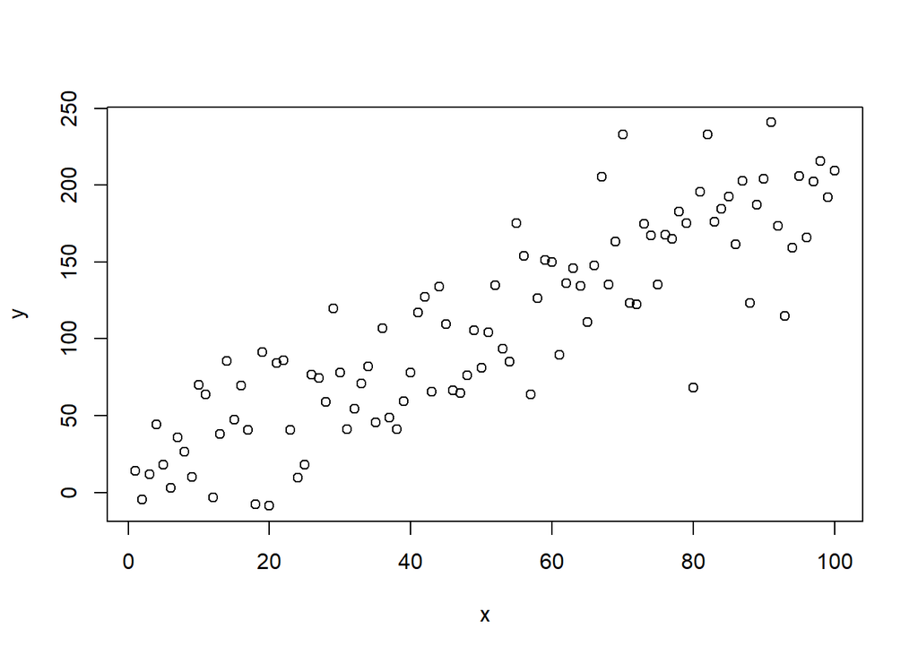

```r
n <- 100
x <- 1:n
y <- 5 + 2 * x + rnorm(n, sd = 30)
plot(x, y)
```

The parameter `type ="l"` indicates that we want the points to be connected by lines.

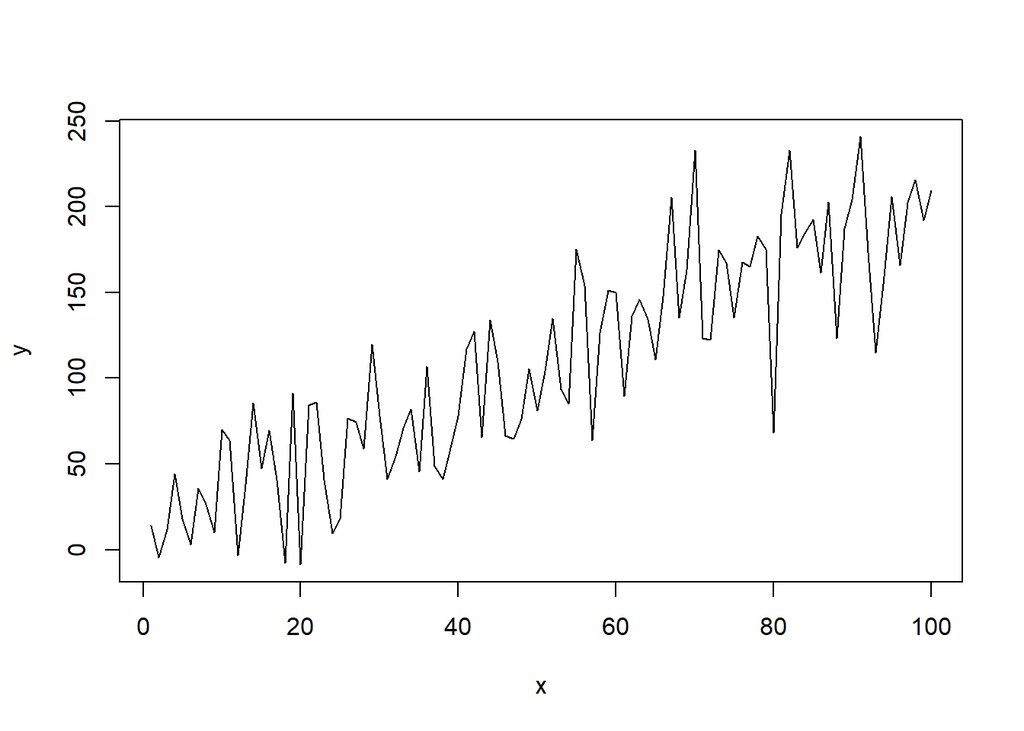

```r
plot(x, y, type = "l")
```

### HISTOGRAM

To construct histograms, we use the `hist()` function. The main parameters are:

- `x` - The numeric vector for which the histogram will be constructed.
- `breaks` - The (approximate) number of rectangles.

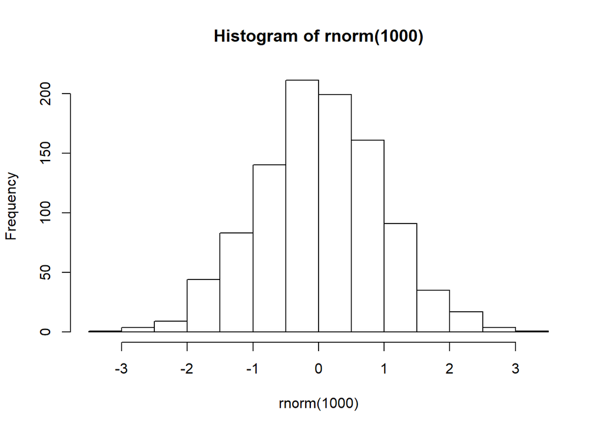

```r
hist(rnorm(1000))
```

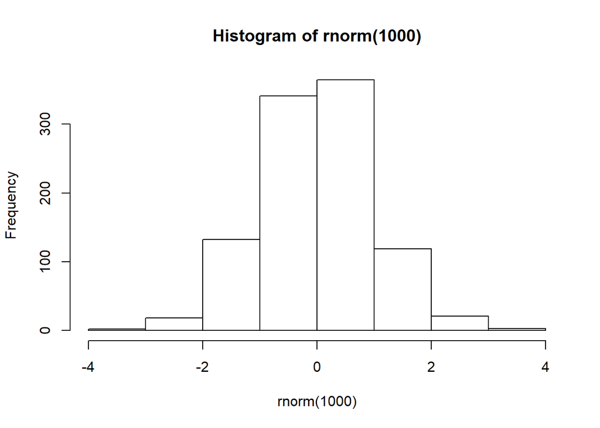

```r
hist(rnorm(1000), breaks = 6)
```

### BOXPLOT

To build boxplot, we use the `boxplot ()` function. The main parameters are: The (approximate) number of rectangles.

- `x` - The numeric vector for which the boxplot will be built.

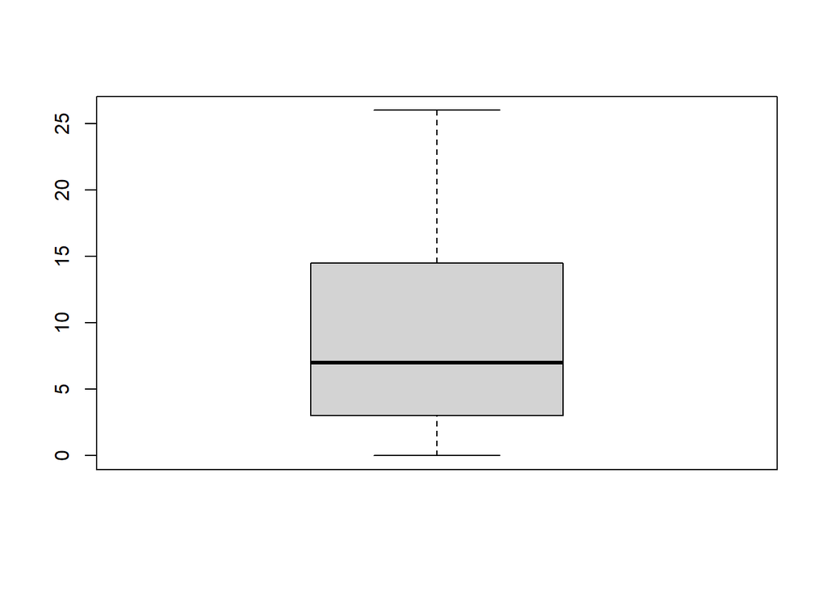

```r
boxplot(InsectSprays$count, col = "lightgray")
```

Note that the `col=colorname` argument changes the color of the boxplot box.

To map two variables to the graph, we use an object of the formula class and the argument `data=`

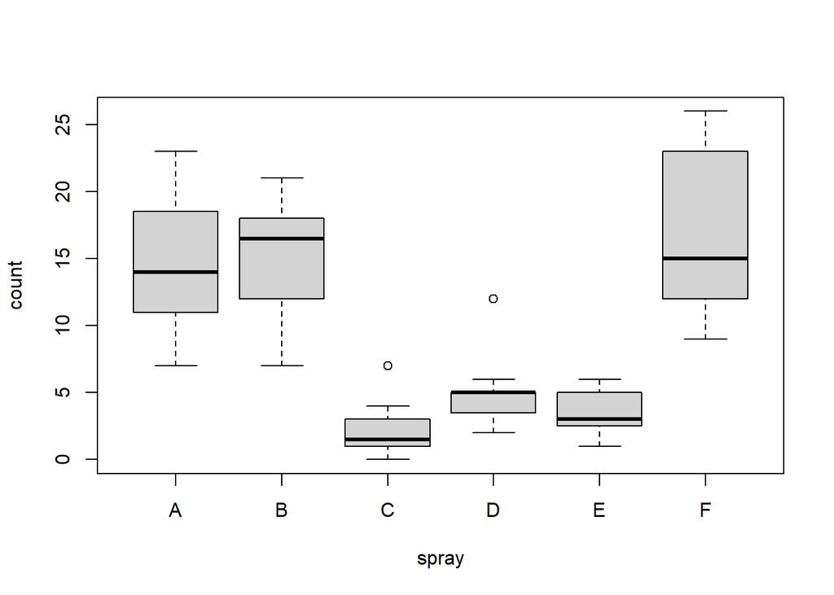

```r
boxplot(count ~ spray, data = InsectSprays, col = "lightgray")
```